# Effects of Trip Characteristics on Their Duration

## Investigation Overview

In this investigation, I wanted to look at the characteristics of trips that could be used to predict their duration. The main focus was on the distance, member age, start day of the week, start hour, type of user, and gender.

## Dataset Overview

The data consisted of duration and attributes of approximately 183,412 trips in San Francisco Bay Area, California. The attributes included the distance, member age, start day of the week, start hour, type of user, and gender. There were some quality and tidiness issues in the dataset and they were fixed. Also, there were some outliers related to duration, distance, and member age discovered during the exploratory phase and they were removed from the dataset to safety reasons.

## Distribution of Trip Duration

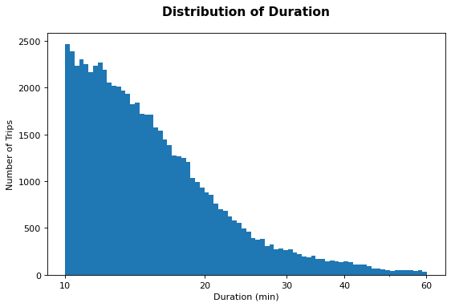

## Distribution of Trip Distance

The distribution of trip distance is right skewed and it has unimodal shape, being the most frequent distance between 1 and 2 kilometers.

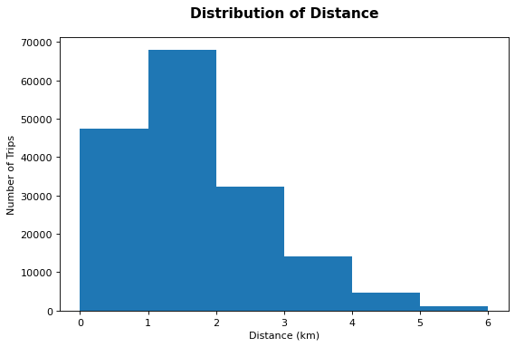

## Distribution of Member Age

The distribution of member age is right skewed and it has unimodal shape. The most frequent range of member age is between 25 and 45 years old.

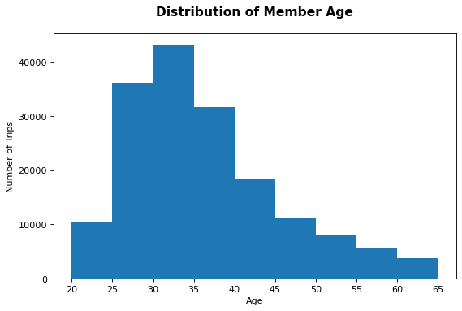

## Proportions of User Type and Member Gender

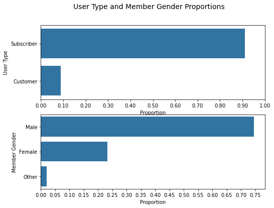

## Duration vs. Distance

This plot suggests that there is a positive correlation between the trip duration and the trip distance. As the trip duration increases the trip distance will increase too.

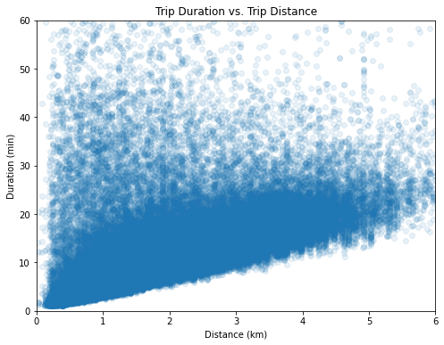

## Trip Duration and Distance by User Type

There is an interaction effect visible between duration, distance, and the member categorical features: user_type, and member_gender. This is most evident for the user type. Subscribers made shorter trips than customers in terms on duration and distance.

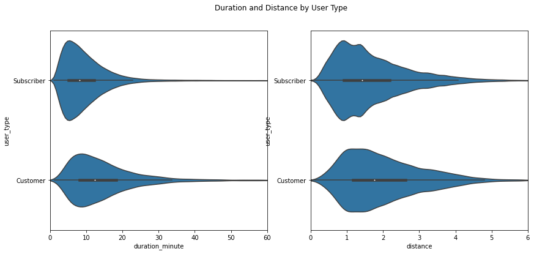

## Trip Duration by User Type and Start Day of Week

Subscribers have a similar duration through all weekdays. Customers made larger trips in terms on duration than subscribers, this difference is specially higher over the weekends.

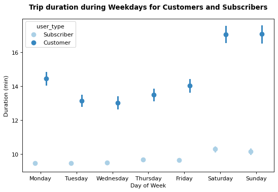

## Hourly Usage by User Type and Start Day of Week

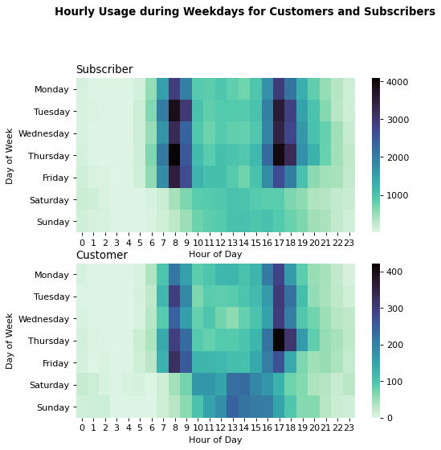